# Ejemplos Generación de Variables Aleatorias

Jorge de la Vega

10 de septiembre de 2020

#Ejemplos Generación de variables aleatorias

## 1. Obtener muestras de una distribución normal truncada

Supongan que queremos generar una muestra de $X\sim N(\mu,\sigma^2)$, truncada al intervalo $(a,b)$.

1. Una manera de hacerlo es generar observaciones de la distribución no truncada y quedarse con los valores que caen en el intervalo.
2. Otra manera es aplicar la transformación inversa con la traslación respectiva: muestra $\nu \sim U(F(a),F(b))$ y obtén $X=F^{-1}(\nu)$.

El primer método puede ser muy costoso si $c = F(b)-F(a)$ es muy pequeño, pues el número promedio de extracciones por cada aceptación es $1/c$.

Para verlo numéricamente, consideremos el siguiente ejemplo concreto: $\mu=2, \sigma=3, a=2, b=4$. Podemos definir las siguientes funciones en R para comparar ambos métodos:

```r
metodo1 <- function(mu,sigma,a,b,n){
 #esta función muestrea de la distribución normal y posteriormente selecciona los casos
 #que caen en el intervalo (a,b) para obtener una muestra truncada de la normal.
l <- 0 #longitud inicial de la muestra
iter <- 0 #número de iteraciones
y <- NULL #vector con los valores aceptados
while(l < n){
  x <- rnorm(1,mean=mu,sd=sigma)
  if(x>=a & x<=b) y <- c(y,x)
  l <- length(y)
  iter <- iter + 1
  next
}
return(list(y=y,iter=iter))
}
```

En esta función es necesario usar la instrucción de control *while* para poder obtener el tamaño de muestra deseado, ya que el número de rechazos es una variable aleatoria.

Evaluando el método 1 podemos ver que la muestra se comporta como se espera:

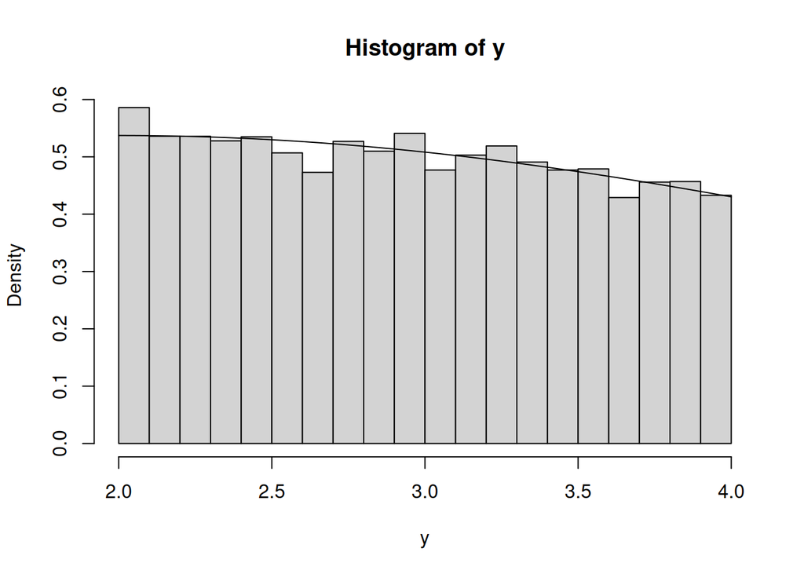

```r
mu <- 2; sigma <- 3; a<- 2; b <- 4; n <- 10000
y <- metodo1(mu=mu,sigma=sigma,a=a,b=b,n=n)$y
x <- seq(a,b,length.out = n)
hist(y,prob=T)
lines(x,dnorm(x,mean=mu,sd=sigma)/(pnorm(b,mean=mu,sd=sigma)-pnorm(a,mean=mu,sd=sigma)))
```

Ahora consideremos el segundo método.

```r
metodo2 <- function(mu,sigma,a,b,n){
  #Esta función obtiene una muestra de la distribución normal a partir de transformación integral
u <- runif(n)
v <- pnorm(a,mean=mu,sd=sigma)+(pnorm(b,mean=mu,sd=sigma)-pnorm(a,mean=mu,sd=sigma))*u
return(qnorm(v,mean=mu,sd=sigma))
}
```

Veamos cómo se ajusta la gráfica de la muestra

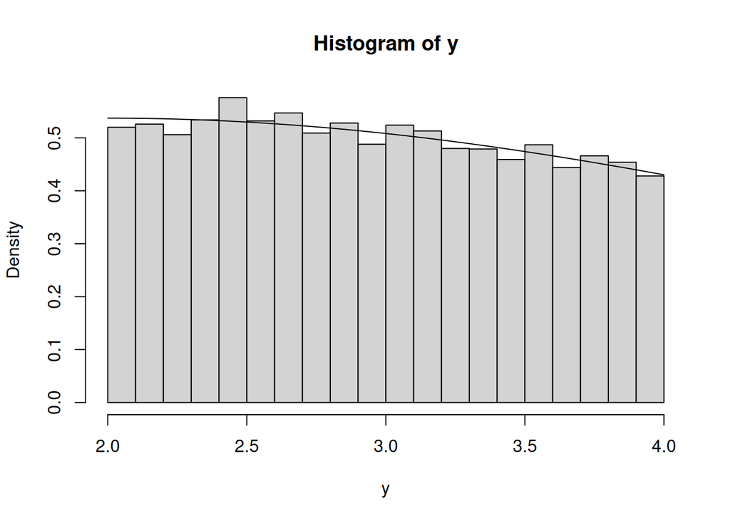

```r
mu <- 2; sigma <- 3; a<- 2; b <- 4; n <- 10000
y <- metodo2(mu=mu,sigma=sigma,a=a,b=b,n=n)
x <- seq(a,b,length.out = n)
hist(y,prob=T)
lines(x,dnorm(x,mean=mu,sd=sigma)/(pnorm(b,mean=mu,sd=sigma)-pnorm(a,mean=mu,sd=sigma)))
```

Comparemos la ejecución de ambos métodos para determinar su eficiencia:

```r
system.time(y1 <- metodo1(mu=2,sigma=3,a=2,b=4,n=100000))
```

```
##    user  system elapsed
##  16.200   0.114  16.488
```

```r
system.time(y2 <- metodo2(mu=2,sigma=3,a=2,b=4,n=100000))
```

```
##    user  system elapsed
##   0.015   0.000   0.015
```

##2. Estadísticas de órden.

El siguiente ejercicio compara los dos métodos vistos en clase para generar las estadísticas de orden de una distribución exponencial. Para fijar ideas consideremos $\lambda=3$, para $n=5$ estadísticas de orden, y consideremos una muestra de la tercera estadística de orden, $X_{(3)}$.

Los métodos a comparar son:

1. Generar una muestra de la distribución objetivo y ordenar los valores para obtener la estadística de orden, y
2. Usar muestras de la distribución Beta, como vimos en el algoritmo descrito en clase.

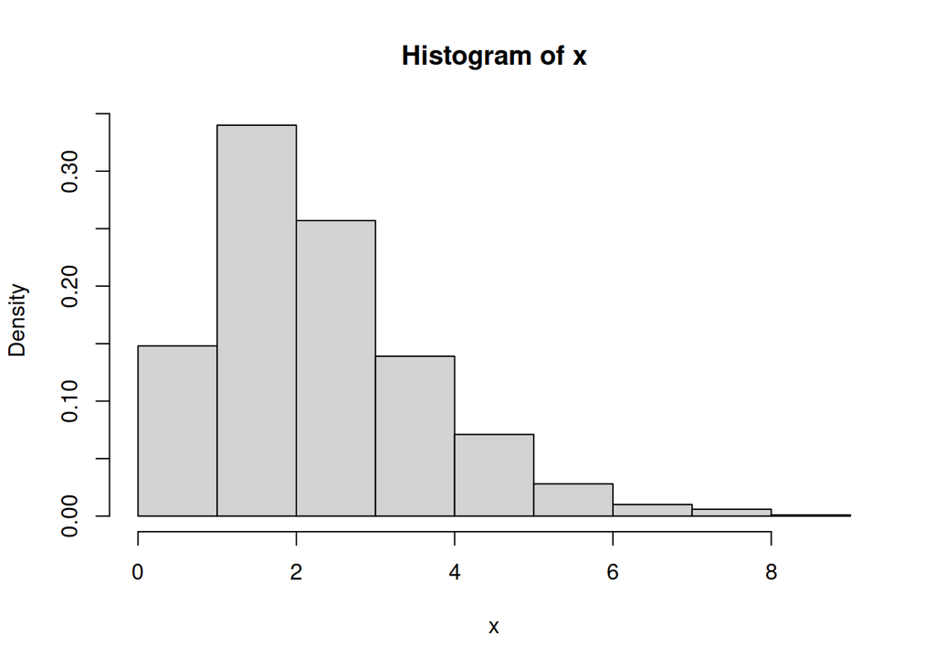

```r
m1 <- function(N,n,k,lambda){
  #Función para generar una muestra de tamaño N de la késima estadística de orden de una
  #muestra de tamaño n de una distribución exp(lambda)
  M <- matrix(-lambda*log(runif(N*n)),nrow=N,ncol=n,byrow=T)
  return(apply(M,1,function(x)sort(x)[k]))
}

x <- m1(1000,5,3,3)
hist(x,prob=T)
```

Para el segundo método, obtenemos la $beta(i,n-i+1)$ a través del método de aceptación-rechazo. Es fácil probar que podemos usar como cobertura la uniforme con la constante que alcanza el óptimo en $x= \frac{i-1}{n-1}$.

```r
rbeta1 <- function(N,n,i){
  #esta función obtiene una muestra aleatoria de tamaño N de una beta(i,n-i+1)
  M <- choose(n,i)*i*((i-1)/(n-1))^(i-1)*((n-i)/(n-1))^(n-i)
  y <- NULL
  l <- 0
  while(l<N){
    u1 <- runif(1)
    if(runif(1) < M*u1^i*(1-u1)^(n-i))y <- c(y,u1)
    l <- length(y)
    next
  }
  return(y)
  }
```

El segundo método nos da:

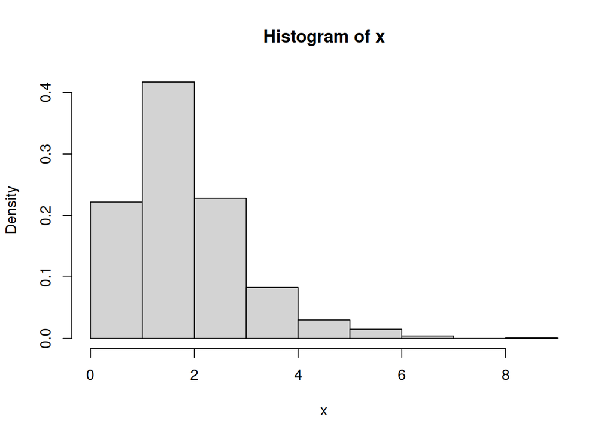

```r
m2 <- function(N,n,k,lambda){
  #Función para generar una muestra de tamaño N de la késima estadística de orden de una
  #muestra de tamaño n de una distribución exp(lambda)
  v <- rbeta1(N,n,k)
  return(-lambda*log(v))
}

x <- m2(1000,5,3,3)
hist(x,prob=T)
```

Un tercer método (por completes) similar al método 2, pero usando el generador de R

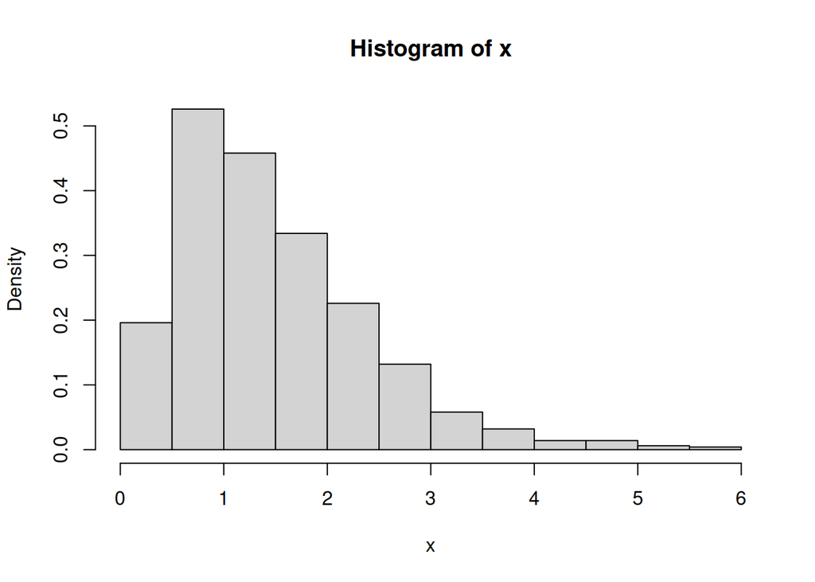

```r
m3 <- function(N,n,k,lambda){
  #Función para generar una muestra de tamaño N de la késima estadística de orden de una
  #muestra de tamaño n de una distribución exp(lambda)
  v <- rbeta(N,n,k)
  return(-lambda*log(v))
}

x <- m3(1000,5,3,3)
hist(x,prob=T)
```

Comparamos los métodos:

```r
system.time(m1(10000,5,3,3))
```

```
##    user  system elapsed
##   0.725   0.000   0.729
```

```r
system.time(m2(10000,5,3,3))
```

```
##    user  system elapsed
##   2.188   0.000   2.202
```

```r
system.time(m3(10000,5,3,3))
```

```
##    user  system elapsed
##   0.005   0.000   0.006
```

##3. Generación de Normales

###3.1 Método TLC

El primer método genera 12 uniformes en (-1/2,1/2). El problema es que la aproximación normal no es muy buena con sólo 12 observaciones.

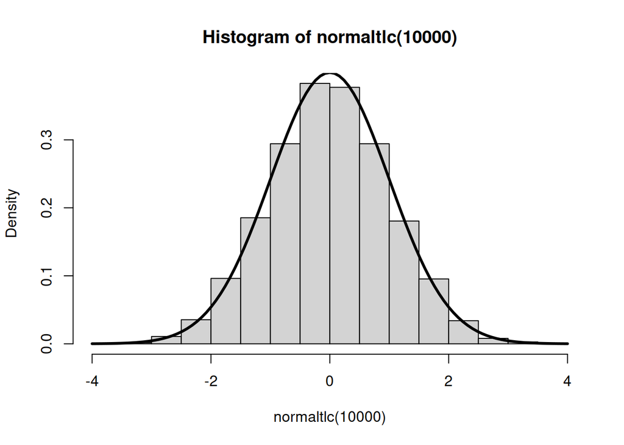

```r
normaltlc <- function(n){
  #Esta función genera n muestras "normales" utiizando la aproximación del TLC
  return(apply(matrix(runif(n*12,min = -0.5,max = 0.5),nrow=n,byrow = F),1,sum))
}

hist(normaltlc(10000),probability = T)
curve(dnorm,add=T,lwd=3)
```

```r
#comparando probabilidades en las colas: podemos ver que la aproximación no es muy buena.
x <- normaltlc(10000)
sum(x>3)/10000
```

```
## [1] 0.0011
```

```r
pnorm(3,lower.tail = F)
```

```
## [1] 0.001349898
```

###Método Box-Müller

Este método se basa en la transformación a coordenadas polares. Genera pares de variables aleatorias normales independientes

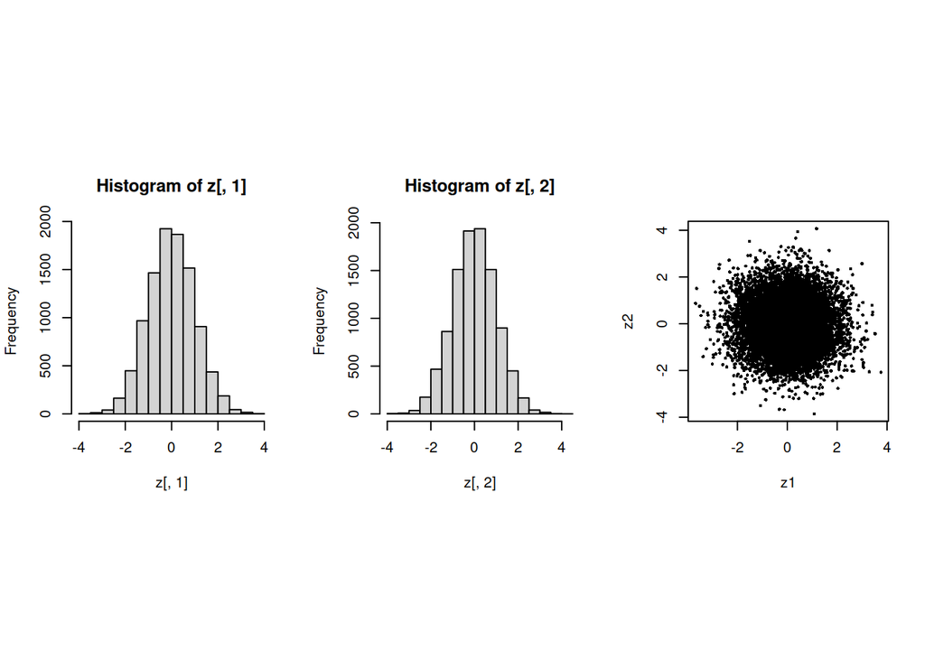

```r
normalBM <- function(n){
    u1 <- runif(n)
    u2 <- runif(n)
        R  <- sqrt(-2*log(u1))
        z1 <- R*cos(2*pi*u2)
        z2 <- R*sin(2*pi*u2)
        return(cbind(z1,z2))
}

z <- normalBM(10000)
par(mfrow=c(1,3))
par(pty="s")
hist(z[,1],breaks=20); hist(z[,2],breaks=20);plot(z,pch=16,cex=0.5)
```

La calidad de los normales dependerán de los números uniformes que se utilicen. En el siguiente ejemplo, usaremos un generador para uniformes congruencial malo (RANDU).

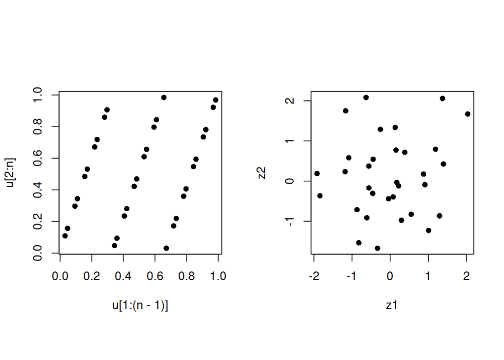

```r
    seed <- 10
    RANDU <- function() {seed <<-(3 * seed+1) %% (64); seed/(64)} #generador RANDU
    u <- NULL; n <- 1000
    for(i in 1:n) u <- c(u,RANDU()) #genera muestra de n uniformes RANDU

    R <- sqrt(-2*log(u[1:(n-1)]))  #Ahora obten normales con Box-Muller
    z1 <- R*cos(2*pi*u[2:n])
    z2 <- R*sin(2*pi*u[2:n])
    par(mfrow=c(1,2))
    par(pty="s")
    plot(u[1:(n-1)],u[2:n],pch=16)
    plot(z1,z2,pch=16)
```

Algunos problemas podrían mejorarse permutando los números uniformes antes de usarlos.

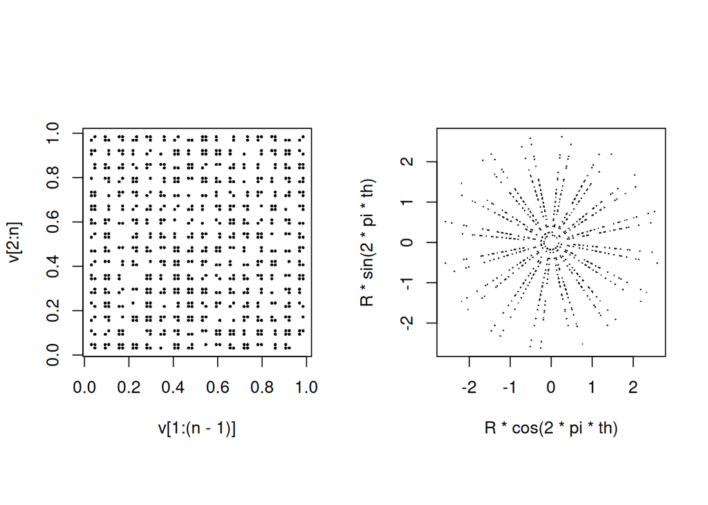

```r
    #Ahora permutamos para mejorar la cobertura.
    v <- sample(u); R <- sqrt(-2*log(v[1:(n-1)])); th <- v[2:n]
  par(mfrow=c(1,2))
  par(pty="s")
    plot(v[1:(n-1)],v[2:n],pch=16,cex=0.4)
    plot( R*cos(2*pi*th), R*sin(2*pi*th), pch=16, cex=0.2)
```